# Tema 8: Teoría Asintótica

Jorge Sosa-García

Primavera 2023

## 8.1. Introducción a la Teoría Asintótica

Hasta ahora sólo hemos hablado de las *propiedades exactas*, también conocidas como **propiedades de muestra finita** de los estimadores de MCO para el modelo poblacional
$$y = \beta_0 + \beta_1 x_1 + \beta_2 x_2 + ... +
\beta_k x_k + u$$
Ahora hablaremos brevemente de las **propiedades asintóticas** de estos estimadores. Estas propiedades no están definidas para un tamaño de muestra en particular, sino que están definidas para cuando el tamaño de muestra crece indefinidamente ($n \rightarrow \infty$).

## 8.2. Consistencia de los Estimadores de MCO

La **consistencia** involucra un experimento mental sobre lo que ocurre con la distribución de un estimador conforme $n \rightarrow \infty$. Si incrementar el tamaño de muestra no nos acerca más y más al valor poblacional del parámetro de interés, entonces estamos usando un mal método de estimación.

En ese sentido, la consistencia es un requerimiento mínimo de cualquier estimador. Clive W. J. Granger decía: “**if you can’t get ir right as** $n$ **goes to infinity, you shouldn’t be in this business**”.

Sean $\hat{\beta}_j$ los estimadores de MCO de los parámetros poblacionales $\beta_j$. Si consideramos los supuestos RLM1 a RLM4 sabemos que estos estimadores son insesgados y, más aún, podemos imaginarnos las distintas distribuciones que estos estiamdores tendrían para valores distintos de $n$.

Si el estimador $\hat{\beta}_j$ es consistente, entonces su distribución se “aglutinará” cada vez más alrededor del valor poblacional $\beta_j$. Esto quiere decir que podemos hacer que nuestro estimador esté tan cerca de $\beta_j$ como queramos si conseguimos un tamaño de muestra lo suficientemente grande.

**TEOREMA: Consistencia de los Estimadores de MCO**  
*Bajo los supuestos RLM1 a RLM4, el estimador de MCO* $\hat{\beta}_j$ *del parámetro poblacional* $\beta_j$ *es consistente para toda* $j = 0, 1, 2, ..., k$.

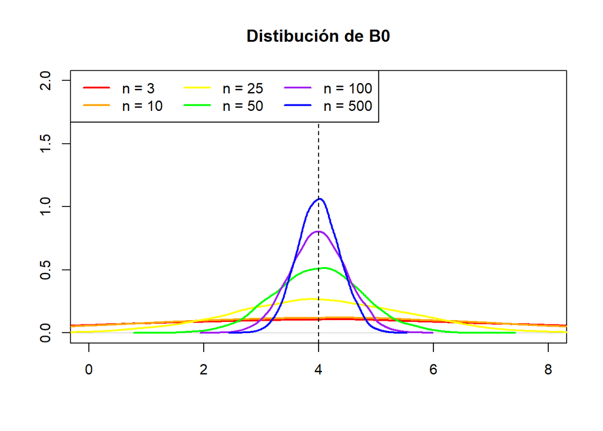

```r
# Replicabilidad
set.seed(700)

# Parametros poblacionales
b0 <- 4
b1 <- 2
sg <- 2

# Definicion de tamaños de muestra
r <- 10000
n1 <- 3
n2 <- 5
n3 <- 10
n4 <- 25
n5 <- 50
n6 <- 100

# Muestreo de tamaño n1
hb0_n1 <- numeric(r)
hb1_n1 <- numeric(r)
x_n1 <- round(runif(n1, 0, 15))
for (j in 1:r){
  u_n1 <- rnorm(n1, 0, sg)
  y_n1 <- b0 + b1 * x_n1 + u_n1
  mod_n1 <- lm(y_n1 ~ x_n1)
  hb0_n1[j] <- coef(mod_n1)[[1]]
  hb1_n1[j] <- coef(mod_n1)[[2]]
}

# Muestreo de tamaño n2
hb0_n2 <- numeric(r)
hb1_n2 <- numeric(r)
x_n2 <- round(runif(n2, 0, 15))
for (j in 1:r){
  u_n2 <- rnorm(n2, 0, sg)
  y_n2 <- b0 + b1 * x_n2 + u_n2
  mod_n2 <- lm(y_n2 ~ x_n2)
  hb0_n2[j] <- coef(mod_n2)[[1]]
  hb1_n2[j] <- coef(mod_n2)[[2]]
}

# Muestreo de tamaño n3
hb0_n3 <- numeric(r)
hb1_n3 <- numeric(r)
x_n3 <- round(runif(n3, 0, 15))
for (j in 1:r){
  u_n3 <- rnorm(n3, 0, sg)
  y_n3 <- b0 + b1 * x_n3 + u_n3
  mod_n3 <- lm(y_n3 ~ x_n3)
  hb0_n3[j] <- coef(mod_n3)[[1]]
  hb1_n3[j] <- coef(mod_n3)[[2]]
}

# Muestreo de tamaño n4
hb0_n4 <- numeric(r)
hb1_n4 <- numeric(r)
x_n4 <- round(runif(n4, 0, 15))
for (j in 1:r){
  u_n4 <- rnorm(n4, 0, sg)
  y_n4 <- b0 + b1 * x_n4 + u_n4
  mod_n4 <- lm(y_n4 ~ x_n4)
  hb0_n4[j] <- coef(mod_n4)[[1]]
  hb1_n4[j] <- coef(mod_n4)[[2]]
}

# Muestreo de tamaño n5
hb0_n5 <- numeric(r)
hb1_n5 <- numeric(r)
x_n5 <- round(runif(n5, 0, 15))
for (j in 1:r){
  u_n5 <- rnorm(n5, 0, sg)
  y_n5 <- b0 + b1 * x_n5 + u_n5
  mod_n5 <- lm(y_n5 ~ x_n5)
  hb0_n5[j] <- coef(mod_n5)[[1]]
  hb1_n5[j] <- coef(mod_n5)[[2]]
}

# Muestreo de tamaño n6
hb0_n6 <- numeric(r)
hb1_n6 <- numeric(r)
x_n6 <- round(runif(n6, 0, 15))
for (j in 1:r){
  u_n6 <- rnorm(n6, 0, sg)
  y_n6 <- b0 + b1 * x_n6 + u_n6
  mod_n6 <- lm(y_n6 ~ x_n6)
  hb0_n6[j] <- coef(mod_n6)[[1]]
  hb1_n6[j] <- coef(mod_n6)[[2]]
}

# Grafica B0
plot(density(hb0_n1),
     col = "red", lwd = 2,
     ylim = c(0, 2), xlim = c(0, 8),
     main = "Distibución de B0",
     xlab = "", ylab = "")
lines(density(hb0_n2), col = "orange", lwd = 2, add = TRUE)
lines(density(hb0_n3), col = "yellow", lwd = 2, add = TRUE)
lines(density(hb0_n4), col = "green", lwd = 2, add = TRUE)
lines(density(hb0_n5), col = "purple", lwd = 2, add = TRUE)
lines(density(hb0_n6), col = "blue", lwd = 2, add = TRUE)
abline(v = b0, col = "black", lty = 2)
legend("topleft", lwd = rep(2, 6),
       col = c("red", "orange", "yellow",
               "green", "purple", "blue"),
       legend = c("n = 3", "n = 10", "n = 25",
                  "n = 50", "n = 100", "n = 500"),
       ncol = 3)
```

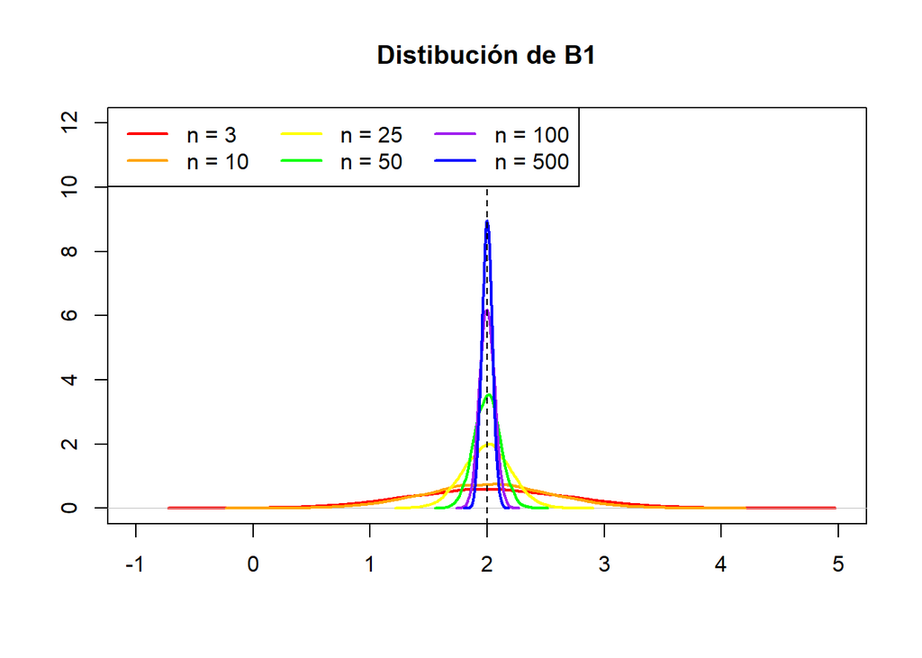

```r
# Grafica B1
plot(density(hb1_n1),
     col = "red", lwd = 2,
     ylim = c(0, 12), xlim = c(-1, 5),
     main = "Distibución de B1",
     xlab = "", ylab = "")
lines(density(hb1_n2), col = "orange", lwd = 2, add = TRUE)
lines(density(hb1_n3), col = "yellow", lwd = 2, add = TRUE)
lines(density(hb1_n4), col = "green", lwd = 2, add = TRUE)
lines(density(hb1_n5), col = "purple", lwd = 2, add = TRUE)
lines(density(hb1_n6), col = "blue", lwd = 2, add = TRUE)
abline(v = b1, col = "black", lty = 2)
legend("topleft", lwd = rep(2, 6),
       col = c("red", "orange", "yellow",
               "green", "purple", "blue"),
       legend = c("n = 3", "n = 10", "n = 25",
                  "n = 50", "n = 100", "n = 500"),
       ncol = 3)
```

## 8.3. Inferencia Estadística con Tamaños de Muestra Grandes

La consistencia de un estimador, aunque muy importante, no es suficiente para poder realizar inferencia estadística.

Para poder hacer pruebas de hipótesis necesitamos la distribución muestral de los estimadores que sabemos, bajos los supuestos CLM, es una distribución normal.

Recordemos que la distribución normal (exacta) de estos estimadores depende, de manera crucial, de que el término de error se distribuya normal. Si el término de error $u$ siguen cualquier otra distribución, entonces los estimadores $\hat{\beta}_j$ no se distribuyen normal, lo que implica que el estadístico $t$ y el estadístico $F$ no siguen distribuciones $t$ y $F$, respectivamente.

Recordemos que el supuesto RLM6 (en conjunto con los demás supuestos Gauss-Markov) se pueden resumir como
$$y | x
\sim N (\beta_0 + \beta_1 x_1 + \beta_2 x_2 + ... + \beta_k x_k ,
\sigma^2)$$

Aún en el caso en en que $y$ no siga una distribución normal, podemos usar el Teorema del Límite Central para concluir que los estimadores de MCO siguen, **aproximadamente**, una distribución normal, al menos cuando se tiene un tamaño de muestra *grande*.

**TEOREMA: Distribución Normal Asintótica de los Estimadores de MCO**  
*Bajo los supuestos de Gauss-Markov*:

- $\sqrt{n} (\hat{\beta}_j - \beta_j) \mathrel{\dot\sim} N(0, \sigma^2 / a_j^2)$*, donde* $\sigma^2 / a_j^2 > 0$ *es la varianza asintótica de* $\sqrt{n} (\hat{\beta}_j - \beta_j)$*. Además,* $a_j^2 = \mathrm{plim} (\frac{1}{n} \sum_{i=1}^{n}\hat{r}_{ij}^2)$*, donde* $\hat{r}_{ij}$ *son los residuales de una regresión de* $x_Jj$ *en todas las demás variables exlicativas.*
- $\hat{\sigma}^2$ *es un estimador consistente de* $\sigma^2 = \mathrm{Var}(u)$.
- *Para cada* $j$:
  $$\frac{\hat{\beta}_j -
  \beta_j}{\mathrm{se}(\hat{\beta}_j)} \mathrel{\dot\sim} N(0,1)$$
  *donde* $\mathrm{se}(\hat{\beta}_j)$ *es el error estándar.*

Este Teorema es bastante útile pues hemos abandonado el supuesto de normalidad en el término de error, y lo único que requerimos ahora es que $u$ tenga varianza finita (lo cual siempre supondremos).

Del Teorema es importante notar que, donde antes se tenía una distribución $t_{n-k-1}$ *exacta*, ahora se tiene una distribución normal *aproximada*. Desde un punto de vista práctico, esta distinción es irrelevante pues la distribución $t$ se aproxima a una distribución normal conforme los grados de libertan aumenta.

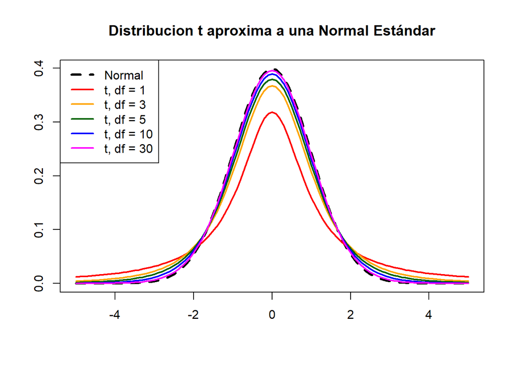

```r
# Distribucion normal
curve(dnorm(x, 0, 1),
      col = "black",
      lwd = 3, lty = 2,
      xlim = c(-5, 5),
      main = "Distribucion t aproxima a una Normal Estándar",
      xlab = "", ylab = "")

# Distribuciones t con diversos df
curve(dt(x, 1), add = TRUE, col = "red", lwd = 2)
curve(dt(x, 3), add = TRUE, col = "orange", lwd = 2)
curve(dt(x, 5), add = TRUE, col = "darkgreen", lwd = 2)
curve(dt(x, 10), add = TRUE, col = "blue", lwd = 2)
curve(dt(x, 30), add = TRUE, col = "magenta", lwd = 2)

# Legend
legend("topleft",
       lty = c(2, 1, 1, 1, 1, 1),
       lwd = c(3, 2, 2, 2, 2, 2),
       col = c("black", "red", "orange",
               "darkgreen", "blue", "magenta"),
       legend = c("Normal", "t, df = 1", "t, df = 3",
                  "t, df = 5", "t, df = 10",
                  "t, df = 30"))
```

Notemos que, cuando los grados de libertad de la distribución $t$ son bajos, entonces la aproximación de la distribución $t$ a la distribución del estadístico $t$ puede no ser ideal cuando el término de error $u$ no se distribuye normal. Desafortunadamente, **no existe un criterio universal de que tan grande tiene que ser el tamaño de muestra para justificar el uso de este argumento asintótico**. Notemos además que esta aproximación no depende del tamaño de muestra, sino de los **grados de libertad** ($df = n-k-1$), lo que significa que si incorporamos más regresores en el modelo, necesitaremos un tamaño de muestra aún mayor.

Otro aspecto importamte del Teorema anterior es que seguimos requieriendo el supuesto de Homocedastricidad del término de error, $\mathrm{Var}[u | x_1, x_2, ..., x_k] = \sigma^2$. Si no se cumple este supuesto, no importa que tan grande sea nuestra muestra, la inferencia estadística que hagamos no será válida.

De manera análoga a lo que platicamos sobre el estadístico $t$, la normalidad asintótica de los estimadores de MCO implica que el estadístico $F$ tiene una distrribición (aproximada) $F$ aún si $u$ no sigue una distribución normal (para tamaños de muestra grandes). Por tanto, realizar pruebas de hipótesis conjuntas no cambia en relación con lo discutido en las propiedades de muestra finita.

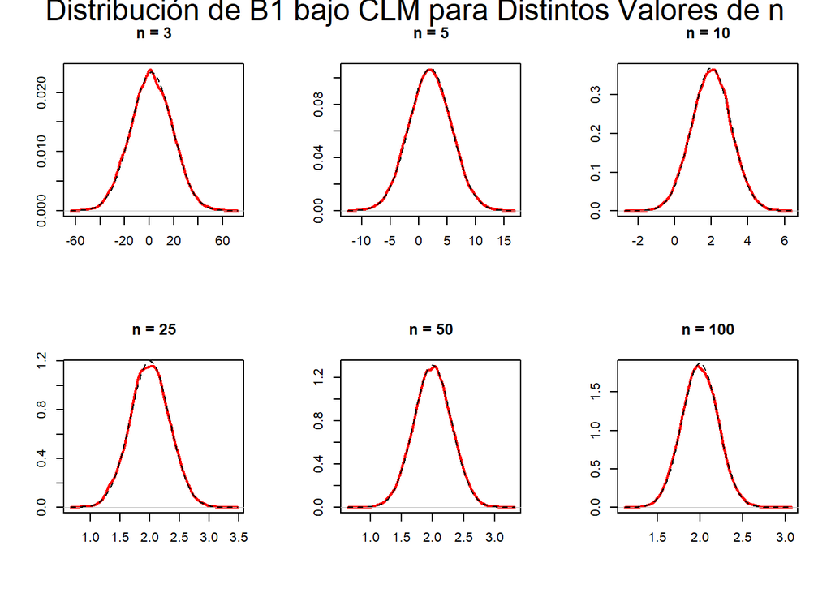

```r
# Replicabilidad
set.seed(700)

# Parametros poblacionales
b0 <- 4
b1 <- 2
sg <- 2

# Definicion de tamaños de muestra
r <- 10000
n1 <- 3
n2 <- 5
n3 <- 10
n4 <- 25
n5 <- 50
n6 <- 100

# Simulacion con muestra n1
x_n1 <- rnorm(n1, 4, 1)
hbt1_n1 <- numeric(r)
for(j in 1:r){
    u_n1 <- rnorm(n1, 0, sg)
    y_n1 <- b0 + b1 * x_n1 + u_n1
    mod_n1 <- lm(y_n1 ~ x_n1)
    hbt1_n1[j] <- coef(mod_n1)[[2]]
}

# Simulacion con muestra n2
x_n2 <- rnorm(n2, 4, 1)
hbt1_n2 <- numeric(r)
for(j in 1:r){
    u_n2 <- rnorm(n2, 0, sg)
    y_n2 <- b0 + b1 * x_n2 + u_n2
    mod_n2 <- lm(y_n2 ~ x_n2)
    hbt1_n2[j] <- coef(mod_n2)[[2]]
}

# Simulacion con muestra n3
x_n3 <- rnorm(n3, 4, 1)
hbt1_n3 <- numeric(r)
for(j in 1:r){
    u_n3 <- rnorm(n3, 0, sg)
    y_n3 <- b0 + b1 * x_n3 + u_n3
    mod_n3 <- lm(y_n3 ~ x_n3)
    hbt1_n3[j] <- coef(mod_n3)[[2]]
}

# Simulacion con muestra n4
x_n4 <- rnorm(n4, 4, 1)
hbt1_n4 <- numeric(r)
for(j in 1:r){
    u_n4 <- rnorm(n4, 0, sg)
    y_n4 <- b0 + b1 * x_n4 + u_n4
    mod_n4 <- lm(y_n4 ~ x_n4)
    hbt1_n4[j] <- coef(mod_n4)[[2]]
}

# Simulacion con muestra n5
x_n5 <- rnorm(n5, 4, 1)
hbt1_n5 <- numeric(r)
for(j in 1:r){
    u_n5 <- rnorm(n5, 0, sg)
    y_n5 <- b0 + b1 * x_n5 + u_n5
    mod_n5 <- lm(y_n5 ~ x_n5)
    hbt1_n5[j] <- coef(mod_n5)[[2]]
}

# Simulacion con muestra n6
x_n6 <- rnorm(n6, 4, 1)
hbt1_n6 <- numeric(r)
for(j in 1:r){
    u_n6 <- rnorm(n6, 0, sg)
    y_n6 <- b0 + b1 * x_n6 + u_n6
    mod_n6 <- lm(y_n6 ~ x_n6)
    hbt1_n6[j] <- coef(mod_n6)[[2]]
}

# Grid
par(mfrow = c(2, 3))

# Grafica n1
plot(density(hbt1_n1), col = "red", lwd = 2, lty = 1,
     main = "n = 3", xlab = "", ylab = "")
curve(dnorm(x, b1, sd(hbt1_n1)), lty = 2, add = TRUE)

# Grafica n2
plot(density(hbt1_n2), col = "red", lwd = 2, lty = 1,
     main = "n = 5", xlab = "", ylab = "")
curve(dnorm(x, b1, sd(hbt1_n2)), lty = 2, add = TRUE)

# Grafica n3
plot(density(hbt1_n3), col = "red", lwd = 2, lty = 1,
     main = "n = 10", xlab = "", ylab = "")
curve(dnorm(x, b1, sd(hbt1_n3)), lty = 2, add = TRUE)

# Grafica n4
plot(density(hbt1_n4), col = "red", lwd = 2, lty = 1,
     main = "n = 25", xlab = "", ylab = "")
curve(dnorm(x, b1, sd(hbt1_n4)), lty = 2, add = TRUE)

# Grafica n5
plot(density(hbt1_n5), col = "red", lwd = 2, lty = 1,
     main = "n = 50", xlab = "", ylab = "")
curve(dnorm(x, b1, sd(hbt1_n5)), lty = 2, add = TRUE)

# Grafica n6
plot(density(hbt1_n6), col = "red", lwd = 2, lty = 1,
     main = "n = 100", xlab = "", ylab = "")
curve(dnorm(x, b1, sd(hbt1_n6)), lty = 2, add = TRUE)

# Titulo
mtext("Distribución de B1 bajo CLM para Distintos Valores de n",
      side = 3, line = -1.5, outer = TRUE,
      cex = 1.50)
```

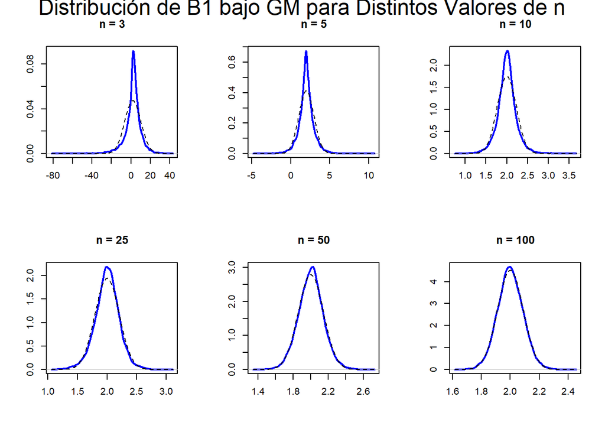

```r
# Replicabilidad
set.seed(700)

# Parametros poblacionales
b0 <- 4
b1 <- 2
sg <- 2

# Definicion de tamaños de muestra
r <- 10000
n1 <- 3
n2 <- 5
n3 <- 10
n4 <- 25
n5 <- 50
n6 <- 100

# Simulacion con muestra n1
hbt1_n1 <- numeric(r)
x_n1 <- rnorm(n1, 4, 1)
for(j in 1:10000){
    u_n1 <- (rchisq(n1, 1) - 1) / sqrt(2)
    y_n1 <- b0 + b1 * x_n1 + u_n1
    mod_n1 <- lm(y_n1 ~ x_n1)
    hbt1_n1[j] <- coef(mod_n1)[[2]]
}

# Simulacion con muestra n2
hbt1_n2 <- numeric(r)
x_n2 <- rnorm(n2, 4, 1)
for(j in 1:10000){
    u_n2 <- (rchisq(n2, 1) - 1) / sqrt(2)
    y_n2 <- b0 + b1 * x_n2 + u_n2
    mod_n2 <- lm(y_n2 ~ x_n2)
    hbt1_n2[j] <- coef(mod_n2)[[2]]
}

# Simulacion con muestra n3
hbt1_n3 <- numeric(r)
x_n3 <- rnorm(n3, 4, 1)
for(j in 1:10000){
    u_n3 <- (rchisq(n3, 1) - 1) / sqrt(2)
    y_n3 <- b0 + b1 * x_n3 + u_n3
    mod_n3 <- lm(y_n3 ~ x_n3)
    hbt1_n3[j] <- coef(mod_n3)[[2]]
}

# Simulacion con muestra n4
hbt1_n4 <- numeric(r)
x_n4 <- rnorm(n4, 4, 1)
for(j in 1:10000){
    u_n4 <- (rchisq(n4, 1) - 1) / sqrt(2)
    y_n4 <- b0 + b1 * x_n4 + u_n4
    mod_n4 <- lm(y_n4 ~ x_n4)
    hbt1_n4[j] <- coef(mod_n4)[[2]]
}

# Simulacion con muestra n5
hbt1_n5 <- numeric(r)
x_n5 <- rnorm(n5, 4, 1)
for(j in 1:10000){
    u_n5 <- (rchisq(n5, 1) - 1) / sqrt(2)
    y_n5 <- b0 + b1 * x_n5 + u_n5
    mod_n5 <- lm(y_n5 ~ x_n5)
    hbt1_n5[j] <- coef(mod_n5)[[2]]
}

# Simulacion con muestra n6
hbt1_n6 <- numeric(r)
x_n6 <- rnorm(n6, 4, 1)
for(j in 1:10000){
    u_n6 <- (rchisq(n6, 1) - 1) / sqrt(2)
    y_n6 <- b0 + b1 * x_n6 + u_n6
    mod_n6 <- lm(y_n6 ~ x_n6)
    hbt1_n6[j] <- coef(mod_n6)[[2]]
}

# Grid
par(mfrow = c(2, 3))

# Grafica n1
plot(density(hbt1_n1), col = "blue", lwd = 2, lty = 1,
     main = "n = 3", xlab = "", ylab = "")
curve(dnorm(x, b1, sd(hbt1_n1)), lty = 2, add = TRUE)

# Grafica n2
plot(density(hbt1_n2), col = "blue", lwd = 2, lty = 1,
     main = "n = 5", xlab = "", ylab = "")
curve(dnorm(x, b1, sd(hbt1_n2)), lty = 2, add = TRUE)

# Grafica n3
plot(density(hbt1_n3), col = "blue", lwd = 2, lty = 1,
     main = "n = 10", xlab = "", ylab = "")
curve(dnorm(x, b1, sd(hbt1_n3)), lty = 2, add = TRUE)

# Grafica n4
plot(density(hbt1_n4), col = "blue", lwd = 2, lty = 1,
     main = "n = 25", xlab = "", ylab = "")
curve(dnorm(x, b1, sd(hbt1_n4)), lty = 2, add = TRUE)

# Grafica n5
plot(density(hbt1_n5), col = "blue", lwd = 2, lty = 1,
     main = "n = 50", xlab = "", ylab = "")
curve(dnorm(x, b1, sd(hbt1_n5)), lty = 2, add = TRUE)

# Grafica n6
plot(density(hbt1_n6), col = "blue", lwd = 2, lty = 1,
     main = "n = 100", xlab = "", ylab = "")
curve(dnorm(x, b1, sd(hbt1_n6)), lty = 2, add = TRUE)

# Titulo
mtext("Distribución de B1 bajo GM para Distintos Valores de n",
      side = 3, line = -1.5, outer = TRUE,
      cex = 1.50)
```

## 8.4. Eficiencia Asíntotica de los Estimadores de MCO

En muestra finita, discutimos que bajo los supuestos Gauss-Markov, los estimadores de MCO eran BLUE. Cuando $n \rightarrow \infty$ (y manteniendo los supuestos Gauss-Markov), los estimadores de MCO también son asintóticamente eficientes dentro de la clase de estimadores lineales:

**TEOREMA: EFICIENCIA ASINTÓTICA DE LOS ESTIMADORES DE MCO**
*Sean* $\tilde{\beta_j}$ *estimadores que son soluciones a ecuaciones de la forma*
$$\sum_{i=1}^{n}g_j(x_i) (y_i - \tilde{\beta_0} -
\tilde{\beta_1} x_1 - ... - \tilde{\beta_k} x_k) \quad \text{para} \quad
j = 0, 1, 2, ..., k$$
*donde* $g_j(x_i)$ *es cualquier función de las variables explicativas de la observación* $i$.
*Sean* $\hat{\beta}_j$ *los estimadores de MCO*.
*Bajo los supuestos de Gauss-Markov, los estimadores de MCO son los de menor varianza asintótica:*
$$A\mathrm{Var}[\sqrt{n} \: (\hat{\beta}_j -
\beta_j)] \leq A\mathrm{Var}[\sqrt{n} \: (\tilde{\beta_j} -
\beta_j)]$$

## 8.5. El Significado de Condicionar en las Variables Explicativas

Existe otra diferencia importante entre las distribuciones de los estimadores de MCO bajo muestras finitas y las distribuciones de los estimadores de MCO bajo el argumento asintótico.

Para los tamaños de muestra finitos, ya hemos establecido que, condicional en las variables explicativas, los estimadores de MCO se distribuyen normal. Esto significa que cada vez que se obtiene una nueva muestra aleatoria, los valores de las variables explicativas permanecen “fijos”, mientras que la variable explicada y el término de error si cambian en cada muestra obtenida.

Este supuesto resulta realista sólo para experimentos extremadamente sencillos donde se puede “elegir” los valores de $x$ para la muestra, realizar sel experimento y medir el valor resultante de la variable $y$.

Naturalmente, esto es un supuesto muy poco realista pues, cuando se obtiene un muestra aleatoria de la población que se está estudiando, obtenemos (de manera simultánea) el valor de $x$ y de $y$. Más aún, los valores $(x_i, y_i)$ serán diferentes en cada muestra que obtengamos.

En estos casos, la distribución condicional sobre los valores de $x$ sólo sirve como una aproximación a la distribución verdadera cuando $x$ está cambiando (sin condicionar). Sin embargo, para tamaños de muestra “grandes”, esta distinción es irrelevante.

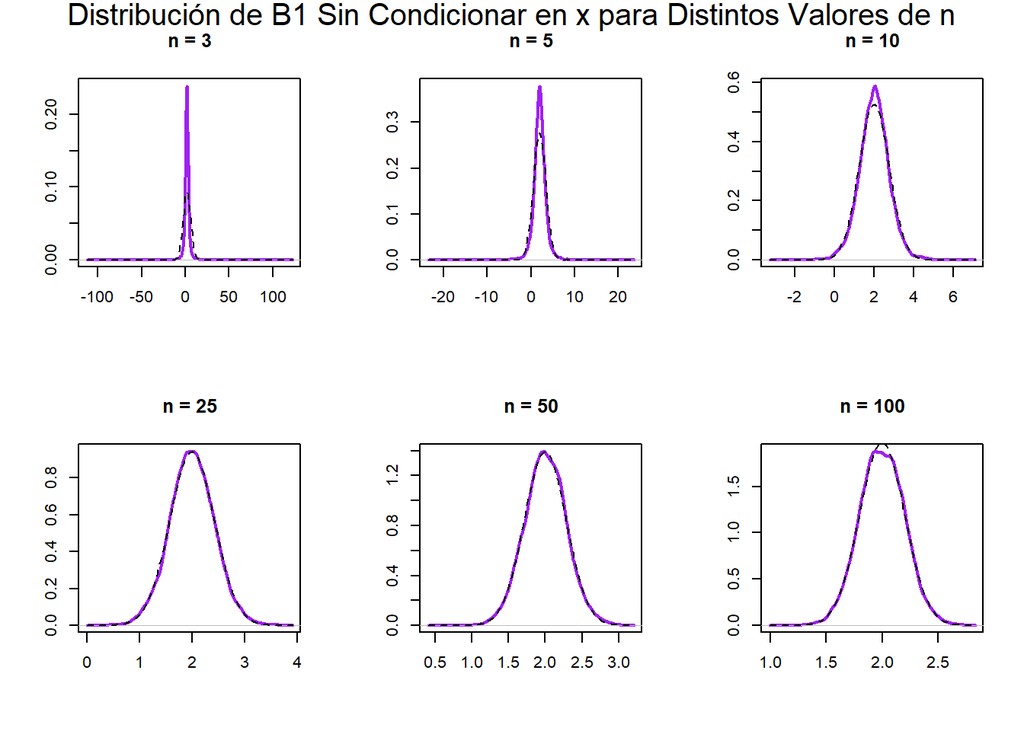

```r
# Replicabilidad
set.seed(700)

# Parametros poblacionales
b0 <- 4
b1 <- 2
sg <- 2

# Definicion de tamaños de muestra
r <- 10000
n1 <- 3
n2 <- 5
n3 <- 10
n4 <- 25
n5 <- 50
n6 <- 100

# Simulacion con muestra n1
hbt1_n1 <- numeric(r)
for(j in 1:r){
    x_n1 <- rnorm(n1, 4, 1)
    u_n1 <- rnorm(n1, 0, sg)
    y_n1 <- b0 + b1 * x_n1 + u_n1
    mod_n1 <- lm(y_n1 ~ x_n1)
    hbt1_n1[j] <- coef(mod_n1)[[2]]
}

# Simulacion con muestra n2
hbt1_n2 <- numeric(r)
for(j in 1:r){
    x_n2 <- rnorm(n2, 4, 1)
    u_n2 <- rnorm(n2, 0, sg)
    y_n2 <- b0 + b1 * x_n2 + u_n2
    mod_n2 <- lm(y_n2 ~ x_n2)
    hbt1_n2[j] <- coef(mod_n2)[[2]]
}

# Simulacion con muestra n3
hbt1_n3 <- numeric(r)
for(j in 1:r){
    x_n3 <- rnorm(n3, 4, 1)
    u_n3 <- rnorm(n3, 0, sg)
    y_n3 <- b0 + b1 * x_n3 + u_n3
    mod_n3 <- lm(y_n3 ~ x_n3)
    hbt1_n3[j] <- coef(mod_n3)[[2]]
}

# Simulacion con muestra n4
hbt1_n4 <- numeric(r)
for(j in 1:r){
    x_n4 <- rnorm(n4, 4, 1)
    u_n4 <- rnorm(n4, 0, sg)
    y_n4 <- b0 + b1 * x_n4 + u_n4
    mod_n4 <- lm(y_n4 ~ x_n4)
    hbt1_n4[j] <- coef(mod_n4)[[2]]
}

# Simulacion con muestra n5
hbt1_n5 <- numeric(r)
for(j in 1:r){
    x_n5 <- rnorm(n5, 4, 1)
    u_n5 <- rnorm(n5, 0, sg)
    y_n5 <- b0 + b1 * x_n5 + u_n5
    mod_n5 <- lm(y_n5 ~ x_n5)
    hbt1_n5[j] <- coef(mod_n5)[[2]]
}

# Simulacion con muestra n6
hbt1_n6 <- numeric(r)
for(j in 1:r){
    x_n6 <- rnorm(n6, 4, 1)
    u_n6 <- rnorm(n6, 0, sg)
    y_n6 <- b0 + b1 * x_n6 + u_n6
    mod_n6 <- lm(y_n6 ~ x_n6)
    hbt1_n6[j] <- coef(mod_n6)[[2]]
}

# Grid
par(mfrow = c(2, 3))

# Grafica n1
plot(density(hbt1_n1), col = "purple", lwd = 2, lty = 1,
     main = "n = 3", xlab = "", ylab = "")
curve(dnorm(x, b1, sd(hbt1_n1)), lty = 2, add = TRUE)

# Grafica n2
plot(density(hbt1_n2), col = "purple", lwd = 2, lty = 1,
     main = "n = 5", xlab = "", ylab = "")
curve(dnorm(x, b1, sd(hbt1_n2)), lty = 2, add = TRUE)

# Grafica n3
plot(density(hbt1_n3), col = "purple", lwd = 2, lty = 1,
     main = "n = 10", xlab = "", ylab = "")
curve(dnorm(x, b1, sd(hbt1_n3)), lty = 2, add = TRUE)

# Grafica n4
plot(density(hbt1_n4), col = "purple", lwd = 2, lty = 1,
     main = "n = 25", xlab = "", ylab = "")
curve(dnorm(x, b1, sd(hbt1_n4)), lty = 2, add = TRUE)

# Grafica n5
plot(density(hbt1_n5), col = "purple", lwd = 2, lty = 1,
     main = "n = 50", xlab = "", ylab = "")
curve(dnorm(x, b1, sd(hbt1_n5)), lty = 2, add = TRUE)

# Grafica n6
plot(density(hbt1_n6), col = "purple", lwd = 2, lty = 1,
     main = "n = 100", xlab = "", ylab = "")
curve(dnorm(x, b1, sd(hbt1_n6)), lty = 2, add = TRUE)

# Titulo
mtext("Distribución de B1 Sin Condicionar en x para Distintos Valores de n",
      side = 3, line = -1.5, outer = TRUE,
      cex = 1.25)
```